# Anomalías térmicas en el Parque Nacional Palo Verde — VIIRS NOAA-21

Detecciones del sensor VIIRS a bordo de NOAA-21 (VIIRS_NOAA21_NRT de NASA FIRMS)

Autor/a

Organización Incendios Forestales

Fecha de publicación

21 de octubre de 2026

## Introducción

Este reporte presenta las anomalías térmicas (detecciones de fuego activo) registradas por el sensor **VIIRS** a bordo del satélite **NOAA-21** en el [Parque Nacional Palo Verde](https://www.sinac.go.cr/), Costa Rica. Es el cuarto de una serie de reportes equivalentes, junto con los de MODIS, VIIRS en Suomi-NPP y VIIRS en NOAA-20.

NOAA-21 es la plataforma más reciente de la constelación VIIRS y lleva el mismo instrumento que Suomi-NPP y NOAA-20, con píxel de 375 m en las bandas de imagen. Como las demás, se publica como serie propia: sus detecciones no se suman a las de las otras plataformas, porque más satélites en órbita significan más oportunidades de observación y una serie combinada mostraría un salto que refleja el instrumental disponible y no el régimen de fuego.

### Tres advertencias propias de esta plataforma

Este reporte se lee distinto de los otros tres, por tres razones que conviene tener presentes desde el principio.

**Primera: todos sus datos son provisionales.** NOAA-21 es la única de las cuatro plataformas que **no tiene procesamiento estándar**. El producto `VIIRS_NOAA21_NRT` es todo lo que existe y no hay fecha prevista para una versión definitiva. Los datos en tiempo casi real se publican en horas, pero su geolocalización y su filtrado de falsas alarmas se refinan cuando la NASA los reprocesa; en las otras plataformas ese reproceso llega, aquí no. En consecuencia, **las cifras de este reporte pueden cambiar entre corridas** y no son estrictamente reproducibles. Las de los otros tres reportes sí lo son, salvo en su tramo final.

**Tercera: el área quemada es prestada.** NOAA-21 tampoco tiene producto de área quemada propio, así que este reporte usa **VNP64A1, derivado de Suomi-NPP**, recortado al período de NOAA-21 y rotulado como «VNP64A1, S-NPP» en cada figura, tabla y leyenda. Es la misma decisión que en el reporte de NOAA-20: el área quemada es una medición distinta —la superficie que quedó marcada, en píxeles de 500 m— y no detecciones de otro sensor mezcladas con las de este. Pero al comparar las dos series de un mismo gráfico se están comparando dos plataformas.

## Mapa animado

Detecciones mensuales de anomalías térmicas; el color indica la potencia radiativa del fuego (FRP).

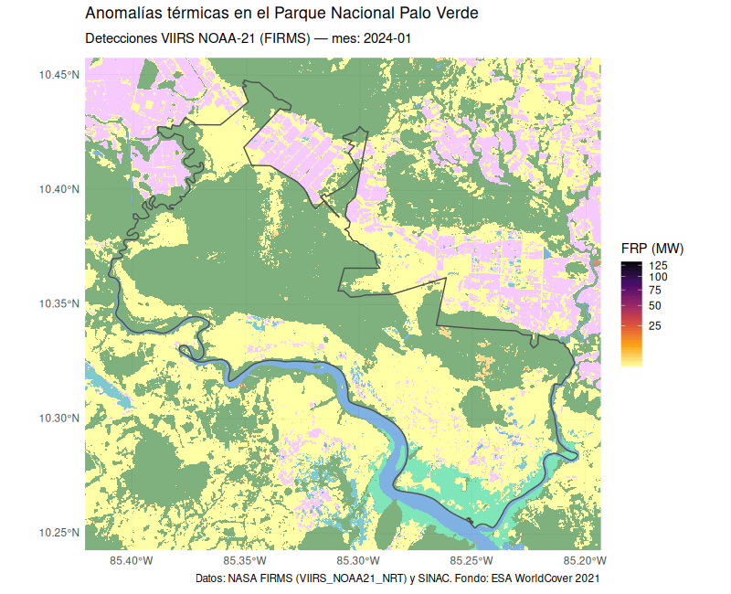

## Video resumen

Resumen mensual en formato de video: detecciones de fuego activo (VIIRS NOAA-21) con su estela de los meses recientes y píxeles de área quemada (VNP64A1, de Suomi-NPP), sobre el relieve del parque teñido por la cobertura de la tierra (WorldCover 2021). El video termina en el último mes con producto de área quemada, porque sus dos contadores son acumulados sincronizados; el mapa interactivo y las series sí llegan hasta el final del registro.

[video not shown]

El cartel estático resume las dos series mensuales. A diferencia del video, conserva el eje completo y marca con una banda el tramo que todavía no tiene producto de área quemada.

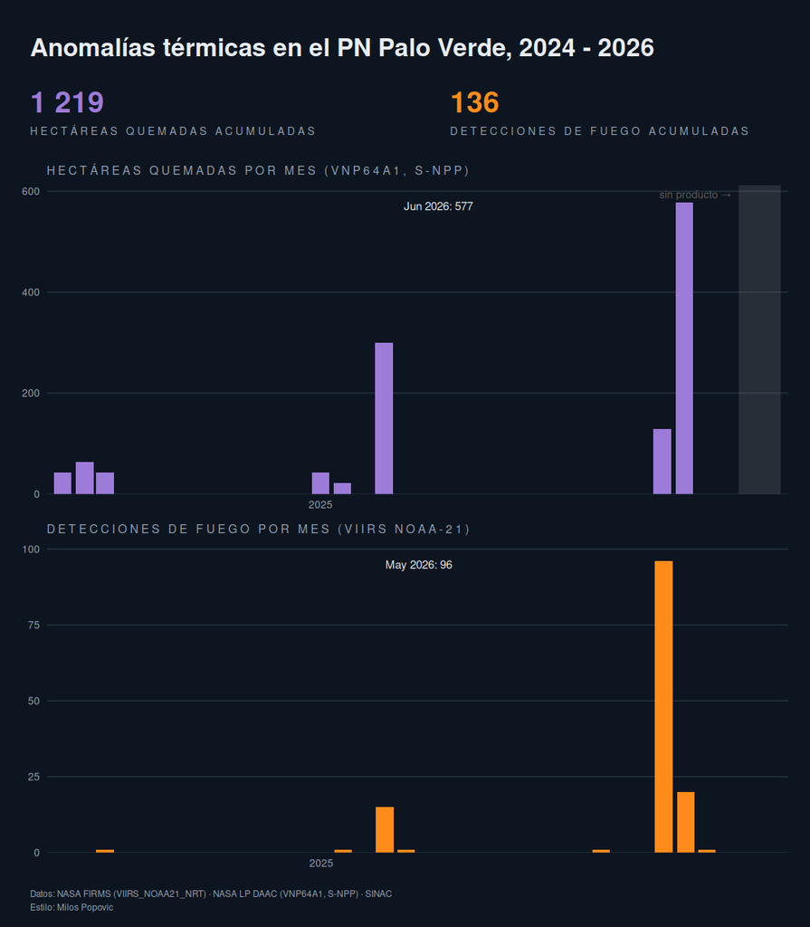

## Mapa interactivo

Use el deslizador temporal para explorar las detecciones a través del tiempo. El botón ⛶ de la esquina superior izquierda abre el mapa en pantalla completa. Cada punto indica su confianza —categórica, como en todos los productos VIIRS— y su nivel de procesamiento, que aquí es siempre «tiempo casi real (provisional)».

[interactive chart not shown]

## Estadísticas

### Serie temporal mensual

Detecciones de fuego activo (arriba) y hectáreas quemadas (abajo), con el eje temporal compartido. Las dos series son complementarias y **no sumables**, y en este reporte provienen además de plataformas distintas. La banda gris del panel inferior marca los meses sin producto de área quemada: no son ceros.

[interactive chart not shown]

### Climatología mensual

Promedios por mes calendario. **Léase con cautela**: con dos estaciones secas y media de registro, cada promedio mensual se apoya en dos o tres valores, y un episodio grande basta para dominar su mes.

[interactive chart not shown]

### Resumen anual

| Año | Detecciones | Hectáreas quemadas | FRP promedio (MW) | FRP máximo (MW) |
| --- | --- | --- | --- | --- |
| 2024 | 1 | 150 | 13.3 | 13.34 |
| 2025 | 17 | 363 | 23.1 | 50.1 |
| 2026 | 118 | 706 | 16.5 | 132.83 |

## Cobertura de la tierra

Cada detección corresponde a un píxel de 375 m en el nadir, por lo que la cobertura se caracteriza sobre el *footprint* completo de la detección —una elipse con las dimensiones reales del píxel— y no sobre el punto exacto.

**Limitación**: WorldCover describe la cobertura de 2021 y el registro abarca 2024–2026.

[interactive chart not shown]

El gráfico gemelo muestra las hectáreas quemadas según la clase dominante del píxel de VNP64A1 (Suomi-NPP).

[interactive chart not shown]

### Contraste con el Registro Nacional de Humedales

| Clase WorldCover | Detecciones | En humedal | % en humedal | Fracción del footprint en humedal | Hectáreas quemadas | % del área quemada en humedal |
| --- | --- | --- | --- | --- | --- | --- |
| Pastizal | 119 | 116 | 97.5 | 0.87 | 919 | 100 |
| Bosque | 14 | 13 | 92.9 | 0.222 | 192 | 33.3 |
| Manglar | 2 | 2 | 100 | 0.577 | 0 |  |
| Cultivos | 1 | 1 | 100 | 1 | 107 | 40 |

El resultado coincide con el de las otras tres plataformas y es el más marcado de las cuatro: el **97,5 %** de las 119 detecciones cuyo footprint domina el *pastizal* de WorldCover caen dentro de un humedal registrado, con un **87 %** del footprint cubierto por humedal en promedio. Cuatro plataformas independientes, con dos resoluciones distintas y registros que van de dos a veinticinco años, coinciden en lo mismo: **las quemas del «pastizal» ocurren en la marisma, no en potreros.**

Vale la advertencia habitual sobre la clase de humedal: el registro asigna una sola clase por polígono, y *Sector Catalina 1* (4 453 ha, clasificado como *Manglar*) cubre casi todo el sector estuarino, por lo que concentra 117 detecciones. Eso **no** significa que esas quemas ocurran en manglar: dentro de ese polígono el manglar cubre el 11,6 % de la superficie según WorldCover y el 4,1 % según la Cobertura Forestal 2023 del SINAC.

## El episodio del humedal Catalina, mayo de 2026

Un registro tan corto como el de NOAA-21 se entiende mejor a través del episodio que lo domina. El 28 de mayo de 2026 la caída de un rayo encendió el interior del humedal Catalina —el sector estuarino de la sección anterior— y una semana después Delfino.cr reportaba, con cifras del Minae-Sinac, que el fuego había afectado **cerca de 4 000 hectáreas** ([nota del 3 de junio de 2026](https://delfino.cr/2026/06/incendio-en-parque-nacional-palo-verde-afecto-cerca-de-4000-hectareas)). El combustible principal fue la *Typha*, una planta invasora que arde incluso sobre el agua. Es el único episodio del registro con una fecha de ignición, una causa y una superficie oficial conocidas: la ocasión de contrastar el satélite contra algo medido en tierra.

**Lo que vio esta plataforma.** NOAA-21 registró **116 detecciones** dentro del parque en 3 días, del 30 de mayo al 1 de junio de 2026 —el fuego apareció en las imágenes 2 días después de la ignición reportada—, con una potencia radiativa acumulada de 1939 MW y un máximo de **132,8 MW**, el valor más alto que registró cualquiera de las cuatro plataformas durante el incendio. 47 de esas detecciones son nocturnas, la proporción más alta de las cuatro: el fuego no se apagaba de noche y NOAA-21 quedó bien situada para verlo.

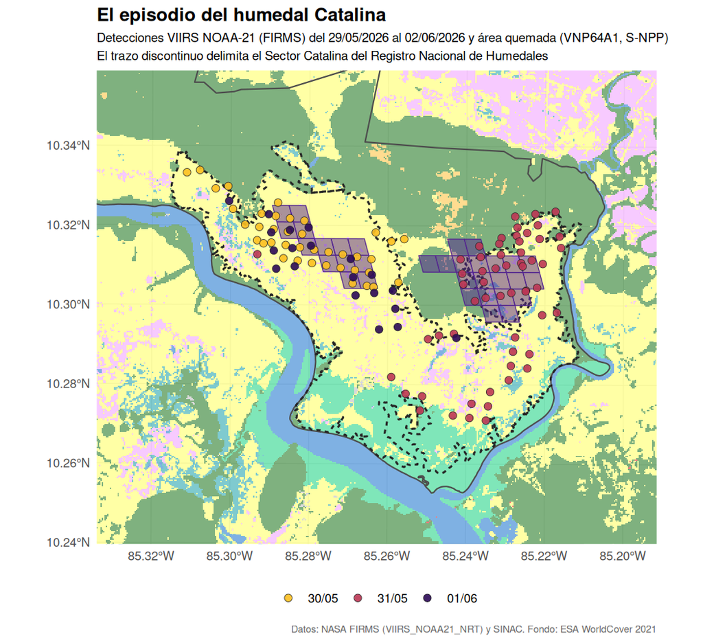

**Dónde ardió.** El **99,1 %** de las detecciones tiene como polígono dominante el *Sector Catalina*, y el **87,9 %** cae en footprints donde WorldCover ve *pastizal*. Es la confirmación externa del hallazgo de la sección anterior: el “pastizal” que arde en Palo Verde no es potrero sino marisma, y esta vez la fuente periodística precisa que lo que ardió fue un typhal sobre agua.

**Lo que el área quemada no vio.** Para mayo y junio de 2026, VNP64A1, S-NPP marca **706 hectáreas** quemadas dentro del parque, frente a las 4 000 reportadas oficialmente: el producto satelital ve **5,7 veces menos superficie** que la contabilizada en tierra. El mapa lo muestra sin necesidad de cifras: las detecciones cubren buena parte del sector, mientras que los píxeles de área quemada forman unas pocas manchas sueltas.

VNP64A1, S-NPP declara quemado un píxel de 500 m cuando detecta un **cambio persistente de reflectancia**, y una quema de *Typha* sobre lámina de agua no lo produce: la vegetación emergente desaparece, el agua vuelve a dominar la señal y a las pocas semanas la superficie se parece a lo que era antes. A eso se suma que el píxel de 500 m no resuelve las cicatrices delgadas e interrumpidas que deja un fuego que avanza entre canales. No es un defecto de este episodio sino el comportamiento esperable del algoritmo en humedales, y advierte contra leer las hectáreas de la tabla anual como una medida de la superficie realmente afectada: **sirven para comparar años entre sí, no para responder cuántas hectáreas se quemaron.**

## ¿El fuego bordea el bosque o lo rodea?

El parque es **54,0 %** bosque y **36,0 %** pastizal según WorldCover, pero solo el **10,3 %** de las detecciones tiene bosque como clase dominante de su footprint, frente al **87,5 %** con pastizal.

Para separar el «efecto de borde» de una ilusión geométrica se compara cada detección contra un modelo nulo de **3000** puntos aleatorios dentro del parque, calculando la fracción de bosque en **500 m** a la redonda.

| Situación paisajística | % de las detecciones | % del área quemada | % esperado por azar |
| --- | --- | --- | --- |
| Abierto (&lt;20 % de bosque alrededor) | 72.05882352941177 | 61.4034634597331 | 33.83333333333334 |
| Borde (20–80 %) | 27.94117647058824 | 36.84215461326566 | 28.2 |
| Interior de bosque (&gt;80 %) | 0 | 1.754381927001239 | 37.96666666666667 |

Sobre las 136 detecciones del registro, el **72,1 %** ocurre en terreno abierto contra un 33,8 % esperado por azar, y en el interior del bosque **no hay ninguna**, frente a un 38,0 % esperado. La mediana de bosque circundante es **0,013** en las detecciones y 0,57 en los puntos aleatorios.

La categoría de borde reúne el **27,9 %** de las detecciones contra un 28,2 % esperado: prácticamente idéntico, sin rastro de preferencia por la línea de contacto con el bosque. La conclusión de los otros tres reportes se sostiene también aquí: **el fuego no bordea el bosque, lo rodea.**

Conviene no leer el cero del interior de bosque como una precisión superior de esta plataforma. NOAA-21 comparte instrumento y píxel de 375 m con Suomi-NPP y NOAA-20, así que la diferencia con ellas no puede atribuirse a la resolución; con 136 detecciones concentradas en pocos episodios, un cero es perfectamente compatible con el 1,7 % de NOAA-20 o el 7,9 % de Suomi-NPP. El argumento sobre resolución solo aplica a la comparación con MODIS, cuyo footprint supera 1 km².

**Limitación**: el modelo nulo supone que cualquier punto del parque tiene la misma probabilidad de arder, lo que ignora factores como la accesibilidad o la cercanía a caminos y linderos.

## Fuentes de datos

- **NASA FIRMS** — Fire Information for Resource Management System, producto VIIRS_NOAA21_NRT (VIIRS 375 m, NOAA-21/JPSS-2, tiempo casi real; **no existe versión de procesamiento estándar**). https://firms.modaps.eosdis.nasa.gov/.
- **NASA LP DAAC** — producto de área quemada VNP64A1 v002 (VIIRS/NPP, mensual, 500 m), **derivado de Suomi-NPP**: no existe equivalente de NOAA-21. Giglio, L., y Justice, C. (2021). *VNP64A1 VIIRS/NPP Burned Area Monthly L4 Global 500m SIN Grid V002*, DOI: 10.5067/VIIRS/VNP64A1.002.
- **SINAC** — Capas de áreas silvestres protegidas (1:5000, 2019), Registro Nacional de Humedales (2016–2018) y Cobertura Forestal 2023, de su servicio WFS. https://geos1pne.sirefor.go.cr/wfs.
- **ESA WorldCover** — cobertura de la tierra 2021 a 10 m, v200. https://esa-worldcover.org/. Zanaga, D., et al. (2022). *ESA WorldCover 10 m 2021 v200*, DOI: 10.5281/zenodo.7254221.

Los reportes análogos: MODIS, VIIRS en Suomi-NPP y VIIRS en NOAA-20.

El código de este análisis está disponible en https://github.com/incendios-forestales/anomalias-termicas-paloverde.